# Fast Growth Firms Prediction Model

Nawal Zehra Hasan

2022-02-17

## EXECUTIVE SUMMARY

An investment company is seeking for potential investment opportunities in firms that have growth potential of at least 30% annually. For this they used prediction analysis using data compiled by Bisnode, a data and analytics company (www.bisnode.com). To achieve this they ran several prediction models including Logit, Lasso, Random Forest to assess the results of each and select the most suitable model giving the lowest average RMSE and highest average AUC.

The loss function with a classification threshold we can turn predicted probabilities into classifications. With this we can look for an optimal threshold in each of our models. Finally, we can decide the best model for prediction according to the lowest average expected loss.

Link to project [Github](https://github.com/nawalhasan/DA3/tree/main/Assignment3) repository.

## DATA CLEANING

The data initially had 287 829 observations on 46,000 firms from 2005 to 2016 with 48 variables. In the end of data cleaning I ended up with 11 910 observations and 116 variables explaining all available information like properties of company, balance sheet, profit and loss elements and management information. Hence I chose that if a company with 30% Compound Annual Growth Rate (CAGR) annual sales growth with be a fast growing firm.

I filtered the data for the 2011-2014 period, and included firms that made a revenue between 1000 - 10 million Euros. I dropped observations with firms that are not active anymore. I also chose. I chose 2011-2012 as two years to see change in sales. I also added explanatory variables such as log of sales, ceo’s age, flagged variables. A dummy variable was created as fast growth for firms with CAGR growth being greater than 30%. The distribution of our key variable, CAGR growth, can be seen below. I included ratios for key financials by dividing all balance sheet elements with total assets, and with profit and loss statement elements.

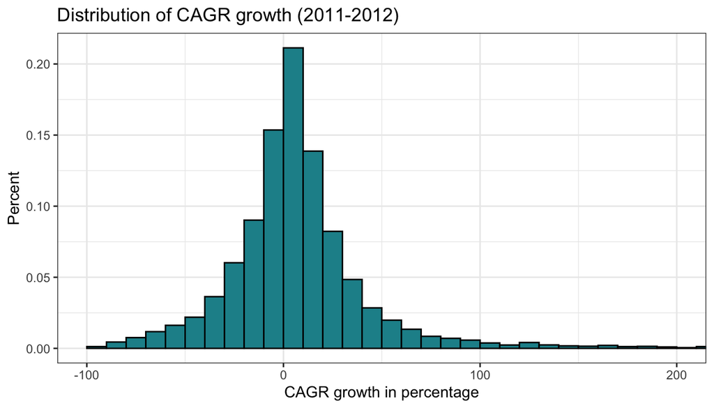

## MODEL SELECTION

I selected the best model for predicting fast growth based on expected losses incurred using each model. As we saw above that random forest model incurred the lowest expect loss followed by logit model 3 and then LASSO. If we want to evaluate using AUC or RMSE, the results will be the same order. After seeing the results, I would still go with logit model 3 which is X3 as my final model. This is because it came out to be the best model for lasso and logit both. Secondly, I believe the simpler the model the more interpretable and solid our results are.

|  | Number.of.predictors | CV.RMSE | CV.AUC | CV.threshold | CV.expected.Loss |
| --- | --- | --- | --- | --- | --- |
| Logit X1 | 11 | 0.3611266 | 0.6546472 | 0.2521809 | 0.4355607 |
| Logit X3 | 35 | 0.3564940 | 0.6922195 | 0.2695752 | 0.4138345 |
| LASSO | 114 | 0.3566997 | 0.6736800 | 0.2295162 | 0.4333248 |
| RF probability | 33 | 0.3541952 | 0.7013841 | 0.2875779 | 0.4087950 |

## THE LOSS FUNCTION

### CONFUSION MATRIX

Now that we have decided on our optimal threshold, we can use our holdout set that we had earlier separated(20% of our observations) and evaluate our best model which is Logit X3. This is the final step part of classification.

The expected loss calculated on the holdout set using logit model X3 is **0.39**. This is lower than the expected loss on the train set. Below we have the confusion matrix from which we can calculate the true positive, true negative, false positive and false negative predictions made by our model.

|  | no_fast_growth | fast_growth |
| --- | --- | --- |
| no_fast_growth | 1836 | 256 |
| fast_growth | 180 | 110 |

## CONCLUSION

Our analysis intended to find out whether a company can have 30% growth in their sales in one year time. My choice of model is logit model 3 with financial variables, firm characteristics, log sales. Among the firms that the model predicted to be fast growing 38% actually turned out to be fast growing. This is much higher than the chances a firm being fast growing in a random sample which was 16%. If a company intends to use our chosen model then it is important that the loss function is very well defined according to the business question at hand. To allow for external validity this model should be applied to a wider time period i.e. every year between 2005 and 2016. We can then see whether the coefficients remain important throughout the decade.